# Homework 3

# Submission Instructions

- Please submit your responses as a nicely formatted notebook (.ipynb) file.
- For questions that require calculations:
  - Show your work (i.e., show the R code you used to answer the question).
  - Make sure all the code you used to answer the question has been run (i.e., displays an output) otherwise you will get a zero for that question.
  - If your *answer* includes many decimal places (e.g., 3.14159265358979), please round it to a reasonable number of decimals for readability (typically 3 to 4).
  - There should be no rounding inside the calculations you do, only round the final result if necessary.
  - For ease of marking, avoid showing the outputs of unnecessary values (short meaningful comments `#` in your code are fine).
  - **If a function or package is prohibited, so are other functions and packages that perform equivalent calculations.**
  - Unless specified otherwise, assume $\alpha = 0.05$.

# Question 1

Some archaeologists theorize that ancient Egyptians interbred with several different immigrant populations over thousands of years. To see if there is any indication of changes in body structure that might have resulted, they measured 30 skulls of male Egyptians dated from 4000 B.C.E. and 30 others dated from 200 B.C.E. We will be using this data to conduct a classic independent t-test to compare the means of the two epochs.

- Thomson and Randall-Maciver, *Ancient Races of the Thebaid*, Oxford: Oxford University Press, 1905.

The data can be found in **“SkullsPartial.csv”**. The column “mb” measures the maximal breadth of the skull.

The data is in the “tidy format”. Find a way to calculate the means for both epochs, as well as the difference between the means. *No special packages are required for this*. You have already learned methods which can help you here.

# Question 2

Using the skull data, calculate the standard deviation and variance for both epochs.

# Question 3

Using the skull data, calculate the pooled variance.

# Question 4

Using the skull data, calculate the pooled standard error.

# Question 5

Calculate a two-sided 95% confidence interval for the difference in mean skull breadth between these two epochs. Use of `t.test()` is not permitted.

# Question 6

Test $H_0: \mu_{_\text{4000}} - \mu_{_\text{200}} = 0$.

Use of `t.test()` is not permitted.

Make sure to report:

- the test statistic
- p-value
- whether your reject or fail to reject the $H_0$

# Question 7

A researcher states their null hypothesis about the skull data as $H_0: \mu_{_\text{4000}} < \mu_{_\text{200}}$.

Another way of expressing this is by writing: $H_0: \mu_{_\text{4000}} - \mu_{_\text{200}} < 0$.

Given the null hypothesis being expressed, answer the following questions:

## a.

Is this a one or two-tailed hypothesis?

## b.

How would you interpret this hypothesis in plain English?

## c.

In which tail is the critical region located for this hypothesis’ test statistic?

## d.

Given what you said in “c.”, which direction should a p-value be calculated? From $-\infty$ upward OR from $+\infty$ downward?

## e.

There are two other mathematically equivalent ways of writing the null hypothesis here. What are they? Your answer should take the form of “$H_0:$________”.

# Question 8

Test $H_0: \mu_{_\text{4000}} - \mu_{_\text{200}} < 0$ or an equivalent version of it. Report the p-value and 95% confidence interval, and state whether you reject the null hypothesis. Use of `t.test()` is not permitted.

# Question 9

Create a barplot of the means for the Skull data. Give each bar two-sided 95% confidence intervals as the errorbars. Have the y-axis go from 110 to 140.

# Question 10

Suppose that the summary stats of your groundbreaking research are . . .

$\bar{x}_1 = 15$

$\bar{x}_2 = 12$

$s^2_1 = 8$

$s^2_2 = 24$

$n_1 = 20$

$n_2 = 10$

Verify that $s^2_p = 13.14$, $T = 2.14$ when rounded to two decimals, and that a classic T-test rejects the null hypothesis of equal means with $\alpha = 0.05$. Compute a confidence interval for this hypothesis test.

# Question 11

Using the information from the previous question, plot the group means and their respective two-sided confidence intervals. Label the two groups A and B. The plot you create should match the plot below. FYI: The colour used is `"aquamarine4"`.

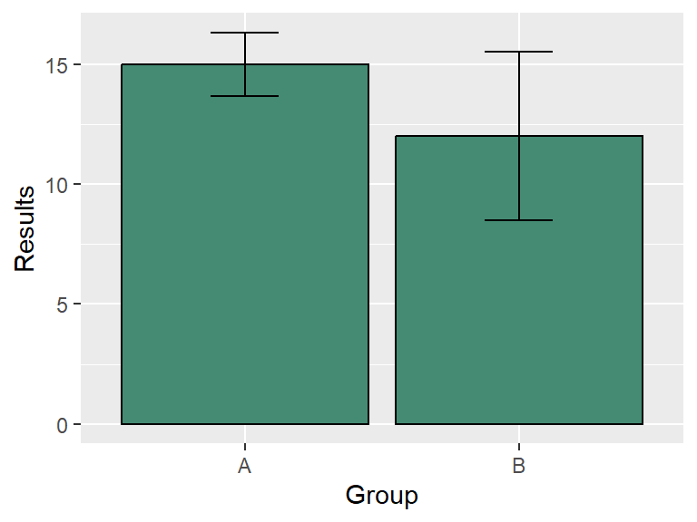

- Hint: To complete this task, you will need to create a data frame containing the relevant values. Since we do not have access to the original dataset, you will not be able to rely on ggplot’s automated methods or the `summarise()` function to generate the necessary summaries.

# Question 12

What is a potentially serious problem for the results seen in the previous question (hint: compare the errorbars)?

# Question 13

Conduct a test that is designed to solve the *specific* problem noted by the previous question. Do the conclusions change from what you got when you ran a classic t-test? Specify the name of the test you ran, its test statistic, degrees of freedom, p-value, and two-sided 95% confidence interval.

# Question 14

Responses to stress are governed, in part, by the hypothalamus. Imagine you have two groups of participants. The first shows signs of heart disease and the other does not. You want to determine whether the groups differ (in any direction) in terms of the weight of the hypothalamus.

Use the data “**heartDisease.csv**” to determine whether the groups differ based on a classic t-test. Use $\alpha = .05$. Use of `t.test()` is not permitted.

Make sure to report:

- the test statistic
- degrees of freedom
- p-value
- Confidence Interval
- Whether your reject or fail to reject the $H_0$

# Question 15

Compute an appropriate measure of effect size for the previous question. Use of `cohen.d()` is not permitted.

# Question 16

Repeat question 14, but use a Welch’s t-test. Use of `t.test()` is not permitted.

# Question 17

Plot the group means with their respective two-sided confidence intervals for the **heartDisease.csv** data.

# Question 18

Repeat question 14 using 20% Trimmed Means. Do you get a different conclusion? Use of `yuen()` is not permitted.

# Question 19

Using the **heartDisease.csv** data set, create a plot showing the 20% trimmed mean for each group, along with their corresponding two-sided confidence intervals.

# Question 20

Generate Q-Q plots to assess the normality assumption of the **heartDisease.csv** data. Should a classic t-test be run on this data?

# Question 21

Generate boxplots to compare the two groups of the **heartDisease.csv** data. Make the boxplots pretty colours.

# Question 22

To investigate the question “*do sexual images in advertisements affect people’s ability to remember the item being advertised*”, a group of statistics students cut ads out of magazines. They were careful to find two ads for each of 10 similar items, one with a sexual image and one without. They arranged the ads in a random order and had 39 subjects look at them for 1 minute. They then asked the subjects to list as many of the products as they could remember. Their data can be found in the file **sexSells.csv**.

Notice that the data is in the tidy format but it is not in a logical order. This is a common problem with data sets. Find a way to *order* the data by the ‘Image’ and ‘Subject’ columns (below is an example of the first 10 rows ordered appropriately). Display the ordered dataset’s full output.

Hint: no special packages are required for this and a basic internet search should give you the solution you desire.

```
## # A tibble: 10 × 3
##    Subject AdRecall Image
##      <dbl>    <dbl> <chr>
##  1       1        2 NotSexy
##  2       2        7 NotSexy
##  3       3        1 NotSexy
##  4       4        5 NotSexy
##  5       5        0 NotSexy
##  6       6        3 NotSexy
##  7       7        5 NotSexy
##  8       8        4 NotSexy
##  9       9        7 NotSexy
## 10      10        4 NotSexy
```

# Question 23

Using $\alpha = 0.05$, assume the data come from a normally distributed population and test the hypothesis that sexual ads are remembered **better** than the nonsexual ads. i.e., $H_0: \mu_{\text{sexy}} - \mu_{\text{notSexy}} > 0$. Use of `t.test()` is not permitted.

Make sure to report:

- the test statistic
- the degrees of freedom
- p-value
- Confidence Interval
- Whether you reject or fail to reject $H_0$

# Question 24

Calculate an appropriate effect size for question 23. What is this effect size telling us? Use of `cohen.d()` is not permitted.

# Question 25

What are the independent and dependent variables in the **sexSells.csv** study?

# Question 26

Plot a bar graph showing the means of both groups and their difference. Give each bar an errorbar that corresponds to a two-sided 95% confidence interval around the mean.

# Question 27

Use a Q-Q plot to assess the normality of the **sexSells.csv** data. Why do you think the plot looks so strange? (You won’t loose marks if your are incorrect).

# Question 28

Repeat question 23 using 20% trimmed means.

- Hint: We never covered a trimmed version of the paired t-test in class; however, we did cover a trimmed version of a one-sample t-test.